# Homework 4 Solution

Matt Lukac

November 10, 2018

## Setup

In this study, we examine how protein levels in the root tissues of *Arabidopsis* plants are affected by their corresponding genotypes, as well as the amount of water given to the plant. The three proteins to be examined are ERD10, NCED9, and SRK2D measured in signal intensity units given by a mass spectrometer.

There were two levels to each factor. The control group for the genotype factor were wild *Arabidopsis* plants, while the experimental group were a collection of plants with a loss-of-function mutation introduced to a gene encoding a heat shock chaperone protein. The control group for the water factor were plants that received a normal amount of daily water, while the experimental group were those that received 10% of a normal amount of daily water.

In what follows, we will be assuming the following about our variables:

| Variable | Properties |
| --- | --- |
| Individual | predictive, nominal, observational |
| Genotype | predictive, categorical, observational |
| Water | predictive, categorical, manipulated |
| ERD10, NCED9, SRK2D | response, discrete |

Since the categorical variables have two levels, we assume they were drawn from a binomial distribution. The intensity units are integers (and hence discrete), so we assume they are Poisson random variables.

## Data Exploration

Let’s take a look at how the protein signal intensities are distributed.

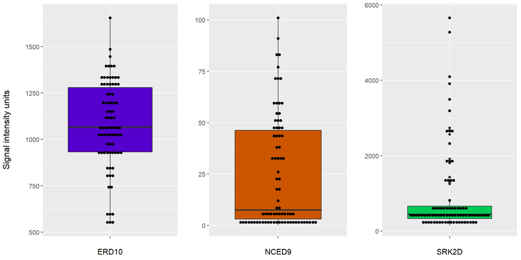

Note the above plots are on drastically different scales. Furthermore, SRK2D has several more outliers than the other two proteins. Perhaps breaking the signal intensities up into the various factor levels will yield different results. This is done in the following plots.

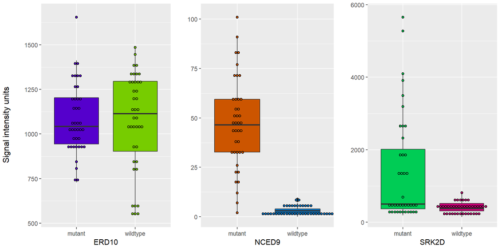

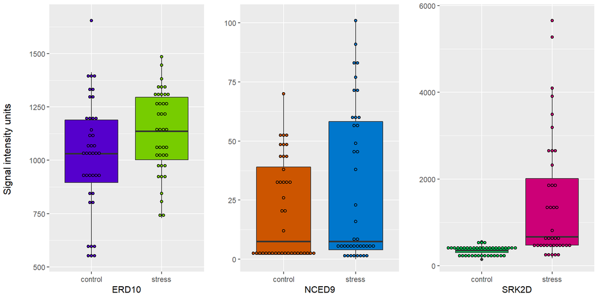

At a glance, ERD10 appears to be relatively unaffected by change of genotype or water treatment. Meanwhile, NCED9 has much lower signal intensity in the wildtype, as compared to the mutant genotype, and yet is relatively unaffected by the water treatment. Interestingly, the SRK2D signal intensities for both control groups are much lower on the average than those in the mutant and stress groups.

To see if any of these observations are significant, we would need to perform a two-factor ANOVA, perhaps with interaction effects. However, this is beyond the scope of this assignment, so instead we’ll just compute some summary statistics for the factor interactions.

| Genotype | Water | ERD10 Mean | ERD10 St.Dev | ERD10 Variance | NCED9 Mean | NCED9 St.Dev | NCED9 Variance | SRK2D Mean | SRK2D St.Dev | SRK2D Variance |
| --- | --- | --- | --- | --- | --- | --- | --- | --- | --- | --- |
| mutant | control | 1164.00 | 203.37 | 41359.47 | 39.15 | 13.85 | 191.71 | 393.05 | 77.19 | 5957.73 |
| mutant | stress | 1004.95 | 154.32 | 23814.37 | 54.90 | 27.41 | 751.36 | 2394.80 | 1521.54 | 2315087.01 |
| wildtype | control | 880.00 | 245.73 | 60384.74 | 2.45 | 0.51 | 0.26 | 313.10 | 90.64 | 8214.83 |
| wildtype | stress | 1259.85 | 132.12 | 17455.29 | 4.55 | 2.48 | 6.16 | 493.10 | 147.57 | 21776.73 |

Starting with the ERD10 columns, we can see the mean signal intensities are approximately uniform when taking the standard deviations into consideration. This supports our previous observation that the ERD10 intensity is generally unaffected by the different treatments.

The mutant *Arabidopsis* plants have a slight increase in mean NCED9 intensity when given less water, but the standard deviation also increases, so this may not be a significant increase. Similar observations hold for the wildtype *Arabidopsis* plants. However, we do see significant decrease in NCED9 intensity between mutant and wildtype plants, regardless of the water treament. These observations are indeed supported by the above boxplots.

The SRK2D intensity drastically increases, on the average, for the stressed mutant *Arabidopsis* plants, as compared to all other treatment combinations. This suggests there may indeed be interaction effects to consider if we were to perform an analysis of variance.

## Regression Assumptions

Now we wish to examine how the three proteins pairwise covary. This will be done via OLS regression. Recall the assumptions we must check for simple linear regression are:

- *Linearity* - this is checked with an appropriate scatterplot to see if the continuous variables covary along a straight line.
- *Normality* - histograms and/or a normal quantile/quantile plot can be used here.
- *Residual Homoscedasticity* - when plotting residuals vs fitted values, we should see residuals evenly spread around the horizontal axis as we move left to right.

Each of the following models will be of the form
$$\begin{align}
y_{i} = \beta_0 + \beta_1 x_i + \varepsilon_{i}
\end{align}$$
where $y_{i}$ is the response protein signal intensity of individual $i$, $x_i$ is the predictor protein intensity of individual $i$, and $\varepsilon_{i}$ is the $i$th residual. Clearly the parameter of interest here is the slope $\beta_1$, so any p-value referenced throughout the models will correspond to the hypotheses
$$\begin{align}
H_0\colon &\beta_1 = 0\\
H_1\colon &\beta_1 \neq 0.
\end{align}$$

We can start by checking the linearity and normality assumptions at the same time. Using `ggpairs` in the `ggAlly` package, we can get a quick idea of how all three protein intensities covary, as well as their approximate distributions.

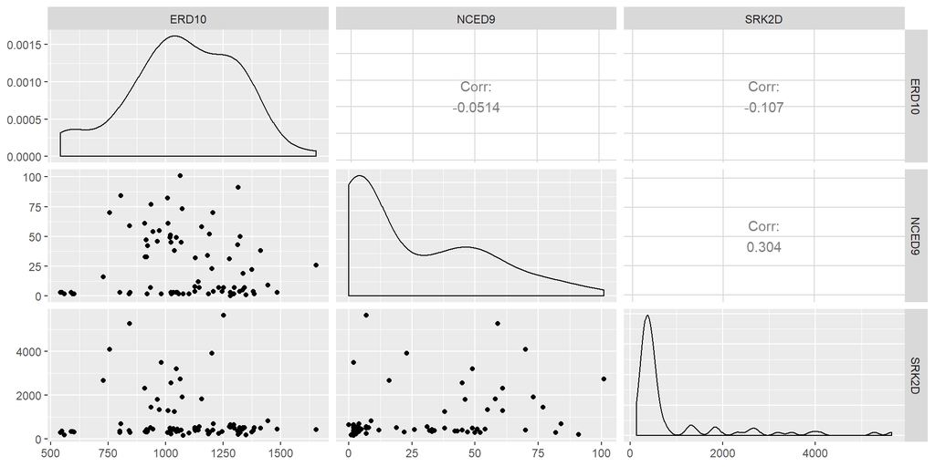

It looks like ERD10 is the only protein intensity with an approximate normal distribution. The scatterplots also show very weak linear trends. There does not appear to be a strong nonlinear trend, however, so we will not worry too much about violating this assumption. Because of this and the reported correlations, we expect the linear models to be non-significant, or weakly significant at best. In summary, the first two OLS assumptions have been more or less violated.

### Model 1: ERD10 vs NCED9

We must perform a residual analysis to check the remaining OLS assumption: residual homoscedasticity. This amounts to also checking the residuals are approximately normal, so we make use of the following plots.

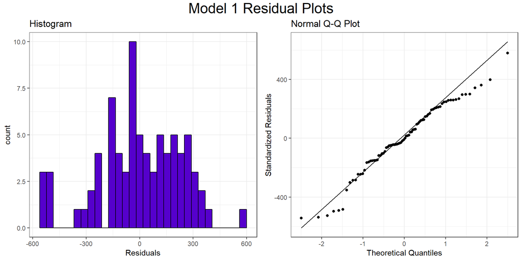

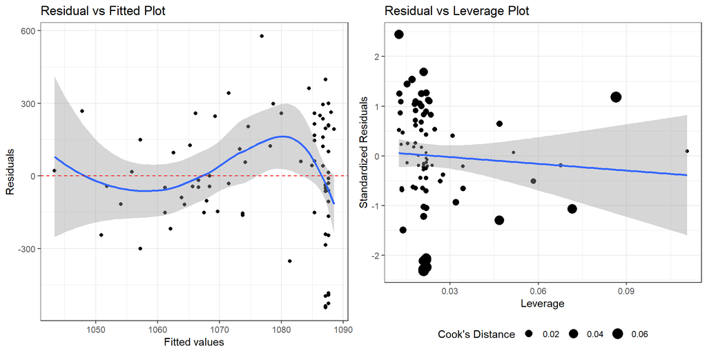

The above four plots tell us much. The top left plot lets us see how close the residuals are to being roughly normal. At first glance they seem close to Gaussian, but the large number of outliers can lead us to believe this assumption has been violated. The top right plot is a way to quantify the normality of the residuals. The closer the points are to the line, the closer the residuals are to being normal. We can see the points oscillating around the diagonal line, and they are far from it on the extremes. We shouldn’t worry too much about these extremem points, since such behavior will happen even if the residuals were sampled from a normal distribution. The oscillatory nature near the center is an indication that the residuals may not be normal.

The bottom left plot is measuring the homoscedasticity of the residuals. If the LOESS trendline were a straight line, we’d be in business. This is not the case, unfortunately, so we cannot say that the residuals are homoscedastic. A nonlinear model may be better in this case. Finally, the bottom right plot measures each residual’s leverage, by way of Cook’s distance metric. A Cook’s distance near 1 is when we should start worrying about outlier residuals, so the model looks good in terms of leverage.

### Model 2: ERD10 vs SRK2D

Similar to the first model, the residuals appear more or less normal, as evident by the top two plots, seen below. The bottom left plot shows the residuals are clearly heteroscedastic, and the bottom right plot has one residual with a Cook’s distance of 0.25, nothing to be worried about.

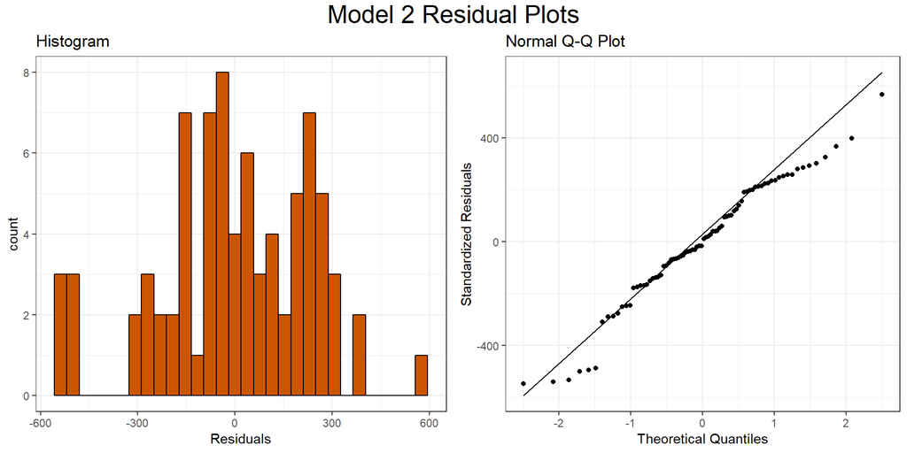

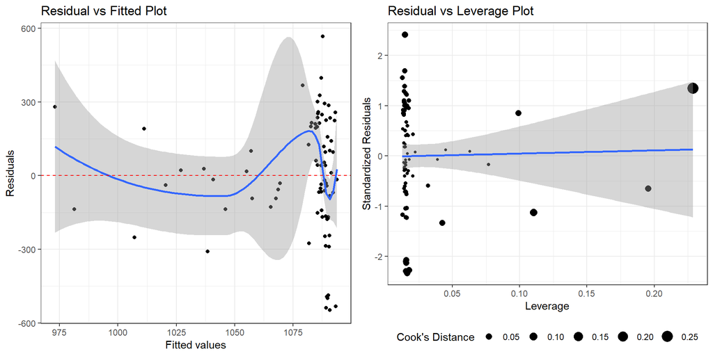

### Model 3: NCED9 vs SRK2D

This is perhaps the furthest from the OLS assumptions. The residuals are clearly neither normal nor homoscedastic. Furthermore, there is an outlier residual with a Cook’s distance of 0.6, so we should look into possibly removing this observation.

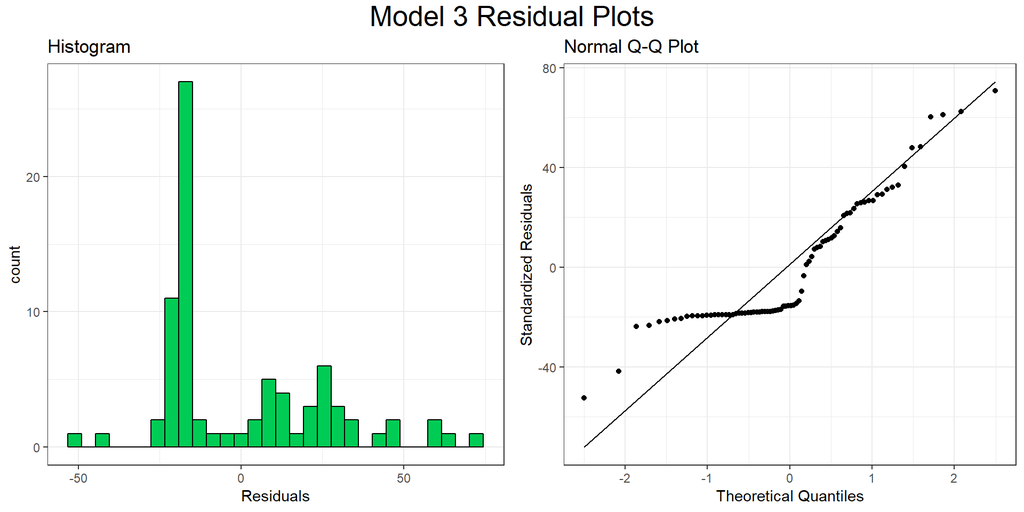

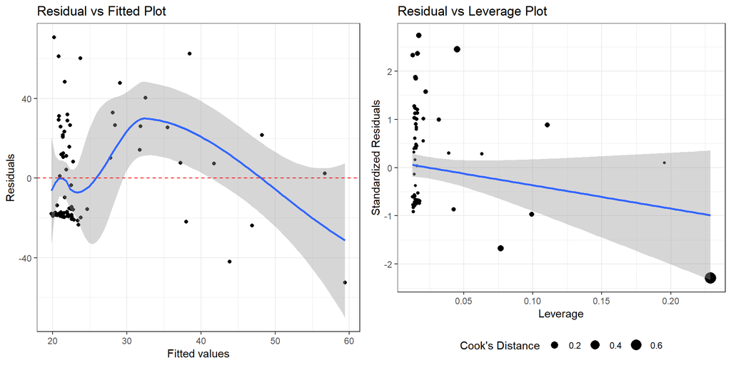

## Results

### Model 1: ERD10 vs NCED9

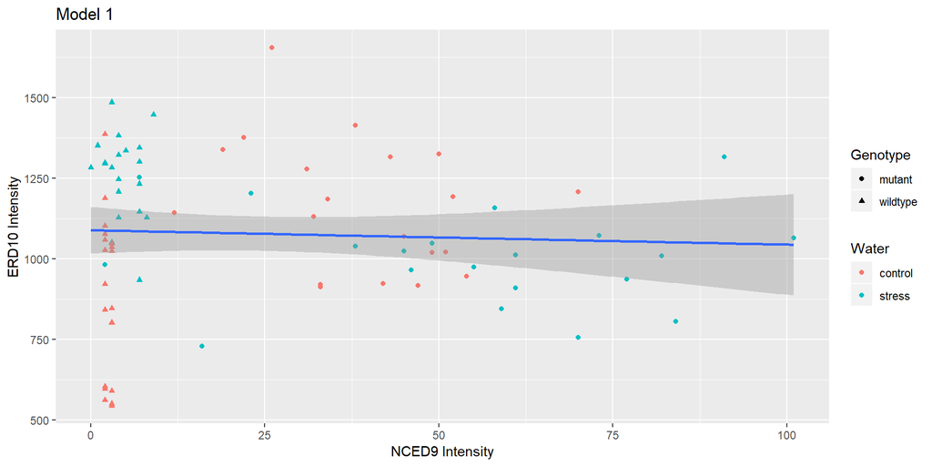

There appears to be little to no trend between these proteins. Based on the factor levels, we may be able to improve the model by breaking the protein intensities up by treatment groups. The reader is encouraged to try this on their own, as it is not of interest for this assignment.

The lack of linear trend in the plot above agrees with the regression results $\left(\hat\beta_1 = -0.447, t = -0.455, p = 0.651, r^2 = 0.003\right)$ at 78 degrees of freedom.. The slope parameter $\beta_1$ had a 95% confidence interval of (-2.404, 1.51). Thus the data do not give sufficient evidence to reject the hypothesis that $\beta_1 = 0$. In other words, there is not enough evidence to suggest the intensities of NCED9 and ERD10 covary.

### Model 2: ERD10 vs SRK2D

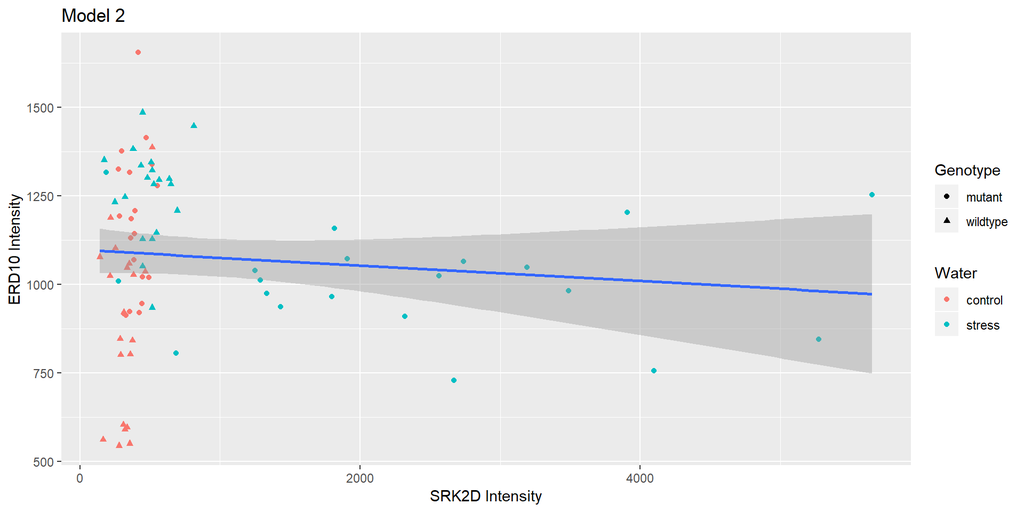

As before, there is little to no visual trend, supported by the regression results $\left(\hat\beta_1 = -0.022, t = -0.947, p = 0.346, r^2 = 0.011\right)$ at 78 degrees of freedom. The slope parameter $\beta_1$ had a 95% confidence interval of (-0.068, 0.024). Thus the data do not give sufficient evidence to reject the hypothesis that $\beta_1 = 0$. In other words, there is not enough evidence to suggest the intensities of SRK2D and ERD10 covary.

### Model 3: NCED9 vs SRK2D

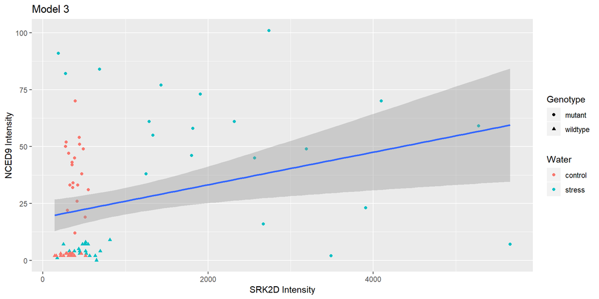

## Summary

We collected signal intesities for the proteins ERD10, NCED9, and SRK2D in *Arabidopsis* plants. The plants were subject to two experimental factors: genotype and water. Each factor had two levels, where genotype was split into wildtype and mutant groups, and the plants were either watered regularly or received just 10% of their regular amount of water (stress).

Some prelimary data exploration showed, depending on the protein, that the signal intensities may or may not have changed with the treatment. The ERD10 protein intensity had little response to varying treatments, while NCED9 had higher mean intensity in the mutant group as compared to the wildtype group, and was relatively unaffected with different water treatments. However, SRK2D responded with a mean increase in signal intensity for both experimental groups (mutant, stress) as compared to both control groups. Performing an ANOVA would rigorously quantify these observations, but was not perform.

#### Acknowledgements

I’ve adapted some code from Carolyn Brewster and Andrew Morris for the boxplots and summary table, respectively.